# MISSING DATA ANALYSIS

ASSIGNMENT 1

Hephaes Chuen Chau (I54105029)

2022-04-06

# Question 1

## (a)

We assume that all for all variables, the missing occurs in the same cases. Therefore, the largest possible subsample is $100-100\times 10\% = 90$

## (b)

We assume that the missing data follow a monotone pattern, meaning that for each variable $10\%$ of the data is deleted. This means the smallest possible subsample is $0$.

## (c)

Let $X_i$ with support $\{0,1\}$ denote the random variable indicating whether case $i$ has at least one missing value in one of the 10 variables (if missing then $X_i=1$). We know therefore by assuming MCAR that
$$\mathbb{P}(X_i = 0) =
(0.9)^{10}$$
A case $i$ is retained in listwise deletion method if and only if $X_i=0$. Thus, the expected number of retained cases is $100\times (0.9)^{10} = 34.8$. This means on average 34 cases are retained.

## (d)

The available sample is larger. In listwise deletion technique, a case is removed as long as there is at least one variable that has missing value. Thus, while the available sample is 100, in (a) we assume all the missing values in different variables occur in a fixed set of cases, then even with this stringent assumption we still have to remove 10 cases from the data.

# Question 2

## (a) Missing rate in each variable

We first remove the unneeded variables and produce a plot

```r
DATA <- read.csv("Diabetes.csv")
for (i in c("location", "gender", "frame")) {
  DATA[,i] <- as.factor(DATA[,i])
}
# Removing unnecessary variables
data <- DATA[,-which(colnames(DATA) %in% c("id", "chol", "stab.glu", "hdl", "ratio", "glyhb", "bp.2d", "bp.1d"))]
missing_rate <- c()
for (i in seq_len(11)) {
  j <- colnames(data)[i]
  Nmissing <- sum(is.na(data[,j]))
  N <- length(data[,j])
  missing_rate[i] <- Nmissing/N
}
names(missing_rate) <- colnames(data)
missing_rate <- as.data.frame(missing_rate)
```

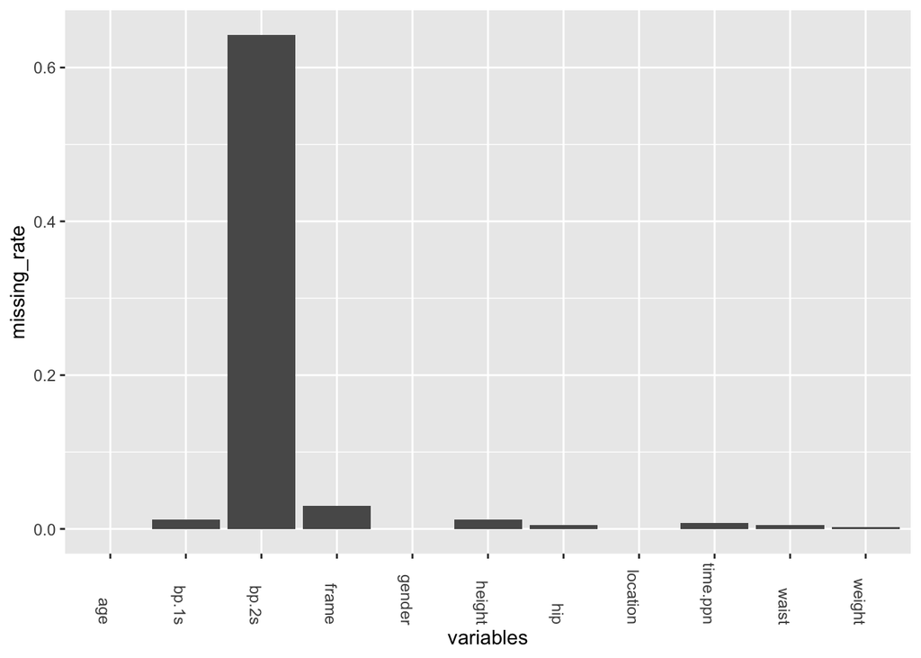

```r
library(ggplot2)
missing_rate$variables <- rownames(missing_rate)
p <-ggplot(data=missing_rate, aes(x=variables, y=missing_rate)) +
  geom_bar(stat="identity") + theme(axis.text.x=element_text(angle=-90, hjust = 1))
p
```

We therefore see that `bp.2s` have particularly high missing rates (exceeding 60%). Next we compare the missing rates of remaining variables, by:

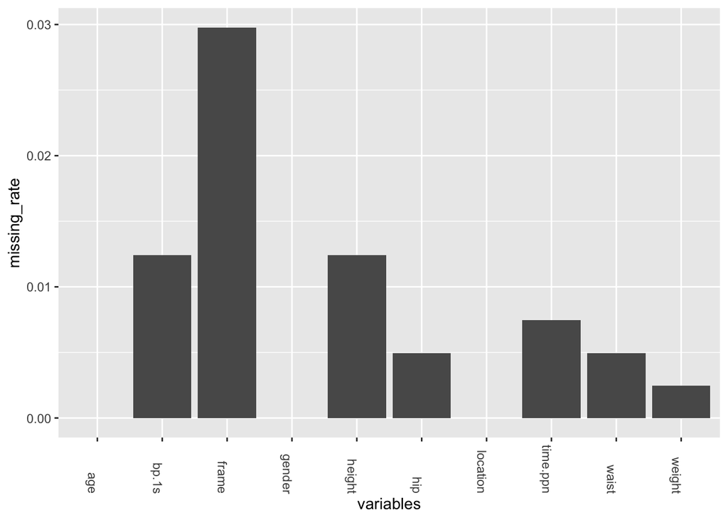

```r
new_missing_rate <- missing_rate[-which(rownames(missing_rate) %in% c("bp.2s","bp.2d")), ]
p2 <-ggplot(data=new_missing_rate, aes(x=variables, y=missing_rate)) +
  geom_bar(stat="identity") + theme(axis.text.x=element_text(angle=-90, hjust = 1))
p2
```

Therefore, of the remaining variables, `frame` has particularly high missing rates (with the latter being close to 3%).

## (d) Missing patterns

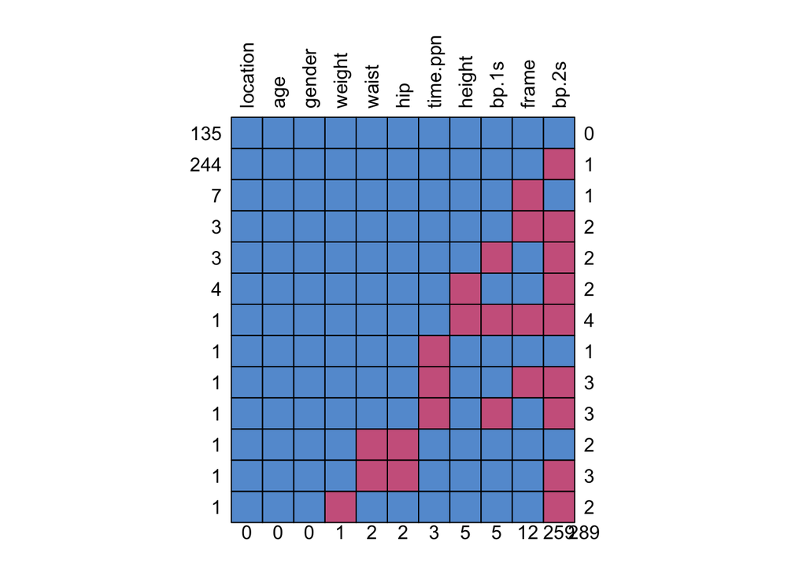

```
##     location age gender weight waist hip time.ppn height bp.1s frame bp.2s
## 135        1   1      1      1     1   1        1      1     1     1     1   0
## 244        1   1      1      1     1   1        1      1     1     1     0   1
## 7          1   1      1      1     1   1        1      1     1     0     1   1
## 3          1   1      1      1     1   1        1      1     1     0     0   2
## 3          1   1      1      1     1   1        1      1     0     1     0   2
## 4          1   1      1      1     1   1        1      0     1     1     0   2
## 1          1   1      1      1     1   1        1      0     0     0     0   4
## 1          1   1      1      1     1   1        0      1     1     1     1   1
## 1          1   1      1      1     1   1        0      1     1     0     0   3
## 1          1   1      1      1     1   1        0      1     0     1     0   3
## 1          1   1      1      1     0   0        1      1     1     1     1   2
## 1          1   1      1      1     0   0        1      1     1     1     0   3
## 1          1   1      1      0     1   1        1      1     1     1     0   2
##            0   0      0      1     2   2        3      5     5    12   259 289
```

```r
library(mice)
md.pattern(data, rotate.names = TRUE)
```

# Question 3

We select `bp.1s` as the response variable.

Before we apply any imputation method, we fit a linear model to the data with the incomplete cases deleted. The purpose of this step is to allow for a comparison of different imputation methods relative to complete case analysis. To conduct the complete case analysis, we fit a linear model on the data, ignoring any case with `NA` in any of the variables, and we conduct a stepwise regression model selection based on AIC.

```r
library(MASS)
ccfit <- lm(data = na.omit(data[,!(colnames(data) %in% "bp.2s")]), bp.1s ~ location + age + gender + height + weight + frame + waist + hip + time.ppn)
ccstep <- stepAIC(ccfit, direction = "both")
```

```
## Start:  AIC=2302.64
## bp.1s ~ location + age + gender + height + weight + frame + waist +
##     hip + time.ppn
##
##            Df Sum of Sq    RSS    AIC
## - height    1       3.5 155607 2300.7
## - location  1      16.2 155620 2300.7
## - gender    1     210.9 155814 2301.2
## - weight    1     265.4 155869 2301.3
## - frame     2    1169.4 156773 2301.5
## - hip       1     389.4 155993 2301.6
## - waist     1     427.5 156031 2301.7
## <none>                  155604 2302.6
## - time.ppn  1     982.5 156586 2303.0
## - age       1   22832.2 178436 2352.5
##
## Step:  AIC=2300.65
## bp.1s ~ location + age + gender + weight + frame + waist + hip +
##     time.ppn
##
##            Df Sum of Sq    RSS    AIC
## - location  1      19.5 155627 2298.7
## - gender    1     268.8 155876 2299.3
## - weight    1     326.0 155933 2299.4
## - frame     2    1186.9 156794 2299.5
## - hip       1     413.4 156021 2299.7
## - waist     1     438.1 156045 2299.7
## <none>                  155607 2300.7
## - time.ppn  1     980.0 156587 2301.0
## + height    1       3.5 155604 2302.6
## - age       1   22908.4 178516 2350.7
##
## Step:  AIC=2298.7
## bp.1s ~ age + gender + weight + frame + waist + hip + time.ppn
##
##            Df Sum of Sq    RSS    AIC
## - gender    1     291.9 155919 2297.4
## - weight    1     341.6 155968 2297.5
## - frame     2    1207.5 156834 2297.6
## - waist     1     425.5 156052 2297.7
```

[output cut: 51 more lines]

```
##
## Step:  AIC=2293.03
## bp.1s ~ age + waist + time.ppn
##
##            Df Sum of Sq    RSS    AIC
## <none>                  157415 2293.0
## - time.ppn  1     958.0 158373 2293.3
## + frame     2    1250.1 156165 2294.0
## + hip       1     188.5 157226 2294.6
## + location  1     112.7 157302 2294.8
## + height    1      34.7 157380 2294.9
## + weight    1      17.3 157398 2295.0
## + gender    1       6.6 157408 2295.0
## - waist     1    3215.9 160631 2298.7
## - age       1   30356.7 187772 2357.9
```

```r
ccstep$anova
```

| Step | Df | Deviance | Resid. Df | Resid. Dev | AIC |
| --- | --- | --- | --- | --- | --- |
|  | NA | NA | 368 | 155603.6 | 2302.644 |
| - height | 1 | 3.534488 | 369 | 155607.2 | 2300.653 |
| - location | 1 | 19.526825 | 370 | 155626.7 | 2298.700 |
| - gender | 1 | 291.926970 | 371 | 155918.6 | 2297.411 |
| - weight | 1 | 133.368251 | 372 | 156052.0 | 2295.735 |
| - hip | 1 | 112.816380 | 373 | 156164.8 | 2294.009 |
| - frame | 2 | 1250.109769 | 375 | 157414.9 | 2293.030 |

```r
summary(ccstep)
```

```
##
## Call:
## lm(formula = bp.1s ~ age + waist + time.ppn, data = na.omit(data[,
##     !(colnames(data) %in% "bp.2s")]))
##
## Residuals:
##     Min      1Q  Median      3Q     Max
## -51.599 -12.655  -2.261   9.420  94.806
##
## Coefficients:
##              Estimate Std. Error t value Pr(>|t|)
## (Intercept) 92.913021   7.414631  12.531  < 2e-16 ***
## age          0.562444   0.066139   8.504 4.42e-16 ***
## waist        0.511407   0.184767   2.768  0.00592 **
## time.ppn    -0.005133   0.003398  -1.511  0.13172
## ---
## Signif. codes:  0 '***' 0.001 '**' 0.01 '*' 0.05 '.' 0.1 ' ' 1
##
## Residual standard error: 20.49 on 375 degrees of freedom
## Multiple R-squared:  0.2004, Adjusted R-squared:  0.194
## F-statistic: 31.33 on 3 and 375 DF,  p-value: < 2.2e-16
```

Therefore, our complete case analysis has settled for `bp.1s ~ age + waist + time.ppn` as the final model to be selected based on AIC. The adjusted R-squared is very low (0.194).

## (a) Mean Imputation

### (i) The imputation

We do mean imputation with the package `mice`, with predictive mean matching for categorical and mean imputation for numerical variables.

```r
library(mice)
mean_imputated_data <- mice(data, defaultMethod = c("mean", "pmm", "pmm", "pmm"), m = 1, maxit = 20, printFlag = FALSE)
md.pattern(complete(mean_imputated_data), rotate.names = TRUE)
```

```
##  /\     /\
## {  `---'  }
## {  O   O  }
## ==>  V <==  No need for mice. This data set is completely observed.
##  \  \|/  /
##   `-----'
```

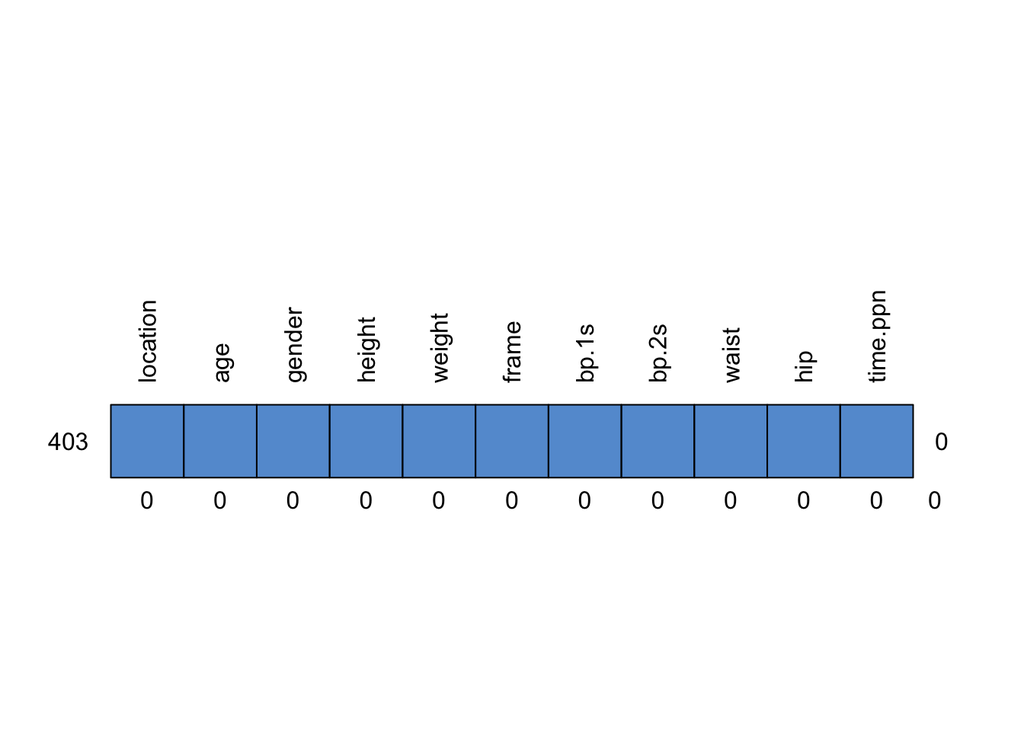

```
##     location age gender height weight frame bp.1s bp.2s waist hip time.ppn
## 403        1   1      1      1      1     1     1     1     1   1        1 0
##            0   0      0      0      0     0     0     0     0   0        0 0
```

### (ii) Stepwise multiple regression

After the imputation, we hope to conduct a multiple regression analysis of the data. We proceed by stepwise regression to select the best model based on AIC, as follows:

```r
fit <- lm(data = complete(mean_imputated_data), bp.1s ~ location + age + gender + height + weight + frame + waist + hip + time.ppn)
library(MASS)
step <- stepAIC(fit, direction = "both")
```

```
## Start:  AIC=2431.06
## bp.1s ~ location + age + gender + height + weight + frame + waist +
##     hip + time.ppn
##
##            Df Sum of Sq    RSS    AIC
## - location  1      16.3 159033 2429.1
## - height    1      53.6 159070 2429.2
## - weight    1     110.5 159127 2429.3
## - waist     1     237.5 159254 2429.7
## - gender    1     292.9 159309 2429.8
## - frame     2    1101.3 160118 2429.8
## - hip       1     390.9 159407 2430.1
## <none>                  159016 2431.1
## - time.ppn  1     937.2 159954 2431.4
## - age       1   27508.2 186525 2493.4
##
## Step:  AIC=2429.11
## bp.1s ~ age + gender + height + weight + frame + waist + hip +
##     time.ppn
##
##            Df Sum of Sq    RSS    AIC
## - height    1      46.3 159079 2427.2
## - weight    1     107.8 159140 2427.4
## - waist     1     253.3 159286 2427.8
## - gender    1     277.7 159310 2427.8
## - frame     2    1091.0 160124 2427.9
## - hip       1     375.2 159408 2428.1
## <none>                  159033 2429.1
## - time.ppn  1     920.9 159954 2429.4
## + location  1      16.3 159016 2431.1
## - age       1   27501.7 186534 2491.4
##
## Step:  AIC=2427.22
## bp.1s ~ age + gender + weight + frame + waist + hip + time.ppn
##
##            Df Sum of Sq    RSS    AIC
## - weight    1     184.9 159264 2425.7
## - gender    1     238.1 159317 2425.8
## - waist     1     264.8 159344 2425.9
## - frame     2    1140.4 160219 2426.1
```

[output cut: 51 more lines]

```
##
## Step:  AIC=2421.46
## bp.1s ~ age + waist + time.ppn
##
##            Df Sum of Sq    RSS    AIC
## <none>                  160762 2421.5
## - time.ppn  1       897 161659 2421.7
## + frame     2      1218 159545 2422.4
## + hip       1       265 160497 2422.8
## + height    1        55 160708 2423.3
## + gender    1        12 160751 2423.4
## + location  1        11 160751 2423.4
## + weight    1         3 160760 2423.5
## - waist     1      3270 164032 2427.6
## - age       1     35542 196305 2500.0
```

```r
step$anova
```

| Step | Df | Deviance | Resid. Df | Resid. Dev | AIC |
| --- | --- | --- | --- | --- | --- |
|  | NA | NA | 392 | 159016.4 | 2431.064 |
| - location | 1 | 16.25665 | 393 | 159032.6 | 2429.105 |
| - height | 1 | 46.28725 | 394 | 159078.9 | 2427.222 |
| - weight | 1 | 184.88334 | 395 | 159263.8 | 2425.690 |
| - gender | 1 | 100.18423 | 396 | 159364.0 | 2423.944 |
| - hip | 1 | 180.72743 | 397 | 159544.7 | 2422.401 |
| - frame | 2 | 1217.73928 | 399 | 160762.5 | 2421.465 |

```r
summary(step)
```

```
##
## Call:
## lm(formula = bp.1s ~ age + waist + time.ppn, data = complete(mean_imputated_data))
##
## Residuals:
##     Min      1Q  Median      3Q     Max
## -52.137 -12.346  -1.625   9.558  94.331
##
## Coefficients:
##              Estimate Std. Error t value Pr(>|t|)
## (Intercept) 92.078885   7.153653  12.872  < 2e-16 ***
## age          0.583164   0.062090   9.392  < 2e-16 ***
## waist        0.505549   0.177458   2.849  0.00462 **
## time.ppn    -0.004855   0.003254  -1.492  0.13647
## ---
## Signif. codes:  0 '***' 0.001 '**' 0.01 '*' 0.05 '.' 0.1 ' ' 1
##
## Residual standard error: 20.07 on 399 degrees of freedom
## Multiple R-squared:  0.217,  Adjusted R-squared:  0.2111
## F-statistic: 36.85 on 3 and 399 DF,  p-value: < 2.2e-16
```

Therefore, with mean imputation, the stepwise model selection based on AIC applied on a family of simple multiple regression models has settled for a model with `age`, `waist` and `time.ppn` as the important explanatory variables. The summary of the final model reveals that only `age` and `waist` have effects significantly different from 0, and the effects of `time.ppn` is very weak. The adjusted R-squared is very low.

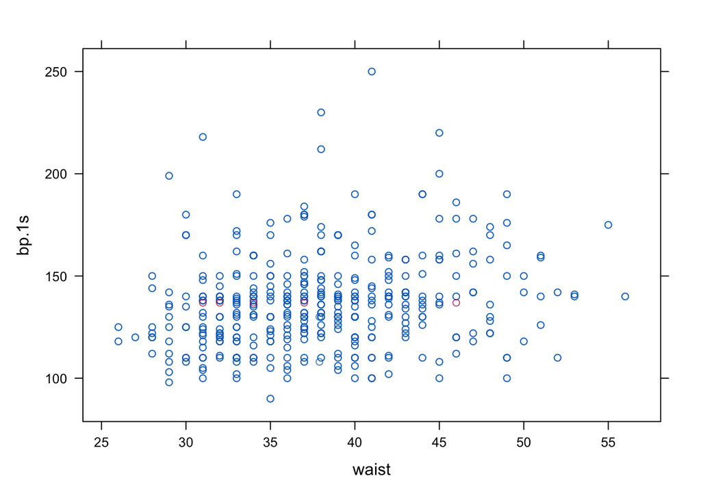

```r
xyplot(mean_imputated_data, bp.1s ~ waist)
```

## (b) Regression imputation and stepwise multiple regression

We use linear regression for numerical variables and polytomous logistic regression for categorical variables.

```r
library(mice)
regr_imputated_data <- mice(data, defaultMethod = c("norm.predict", "polyreg", "polyreg", "polyreg"), m = 1, maxit = 20, printFlag = FALSE)
fit <- lm(data = complete(regr_imputated_data), bp.1s ~ location + age + gender + height + weight + frame + waist + hip + time.ppn)
library(MASS)
step <- stepAIC(fit, direction = "both")
```

```
## Start:  AIC=2429.5
## bp.1s ~ location + age + gender + height + weight + frame + waist +
##     hip + time.ppn
##
##            Df Sum of Sq    RSS    AIC
## - location  1       5.5 158405 2427.5
## - height    1       9.2 158409 2427.5
## - weight    1     203.6 158604 2428.0
## - gender    1     284.4 158684 2428.2
## - waist     1     289.0 158689 2428.2
## - frame     2    1245.7 159646 2428.7
## - hip       1     533.3 158933 2428.8
## <none>                  158400 2429.5
## - time.ppn  1     979.5 159380 2430.0
## - age       1   27079.3 185479 2491.1
##
## Step:  AIC=2427.51
## bp.1s ~ age + gender + height + weight + frame + waist + hip +
##     time.ppn
##
##            Df Sum of Sq    RSS    AIC
## - height    1       7.3 158413 2425.5
## - weight    1     202.0 158608 2426.0
## - gender    1     279.4 158685 2426.2
## - waist     1     300.1 158706 2426.3
## - frame     2    1241.6 159647 2426.7
## - hip       1     529.6 158935 2426.9
## <none>                  158405 2427.5
## - time.ppn  1     977.9 159383 2428.0
## + location  1       5.5 158400 2429.5
## - age       1   27074.2 185480 2489.1
##
## Step:  AIC=2425.53
## bp.1s ~ age + gender + weight + frame + waist + hip + time.ppn
##
##            Df Sum of Sq    RSS    AIC
## - weight    1     262.7 158675 2424.2
## - waist     1     307.1 158720 2424.3
## - gender    1     331.5 158744 2424.4
## - frame     2    1283.1 159696 2424.8
```

[output cut: 51 more lines]

```
##
## Step:  AIC=2420.54
## bp.1s ~ age + hip + time.ppn
##
##            Df Sum of Sq    RSS    AIC
## <none>                  160394 2420.5
## - time.ppn  1       829 161223 2420.6
## + frame     2      1355 159039 2421.1
## + gender    1       340 160054 2421.7
## + waist     1       302 160092 2421.8
## + height    1        29 160365 2422.5
## + weight    1        28 160366 2422.5
## + location  1         1 160393 2422.5
## - hip       1      3624 164018 2427.5
## - age       1     39896 200290 2508.1
```

```r
step$anova
```

| Step | Df | Deviance | Resid. Df | Resid. Dev | AIC |
| --- | --- | --- | --- | --- | --- |
|  | NA | NA | 392 | 158400.0 | 2429.499 |
| - location | 1 | 5.477379 | 393 | 158405.5 | 2427.513 |
| - height | 1 | 7.274155 | 394 | 158412.8 | 2425.531 |
| - weight | 1 | 262.707009 | 395 | 158675.5 | 2424.199 |
| - waist | 1 | 129.520264 | 396 | 158805.0 | 2422.528 |
| - gender | 1 | 234.233435 | 397 | 159039.2 | 2421.122 |
| - frame | 2 | 1354.571370 | 399 | 160393.8 | 2420.540 |

```r
summary(step)
```

```
##
## Call:
## lm(formula = bp.1s ~ age + hip + time.ppn, data = complete(regr_imputated_data))
##
## Residuals:
##     Min      1Q  Median      3Q     Max
## -55.129 -12.988  -1.028   8.752  93.664
##
## Coefficients:
##              Estimate Std. Error t value Pr(>|t|)
## (Intercept) 86.910588   8.365007  10.390  < 2e-16 ***
## age          0.611099   0.061342   9.962  < 2e-16 ***
## hip          0.532274   0.177273   3.003  0.00285 **
## time.ppn    -0.004676   0.003255  -1.436  0.15170
## ---
## Signif. codes:  0 '***' 0.001 '**' 0.01 '*' 0.05 '.' 0.1 ' ' 1
##
## Residual standard error: 20.05 on 399 degrees of freedom
## Multiple R-squared:  0.2204, Adjusted R-squared:  0.2145
## F-statistic:  37.6 on 3 and 399 DF,  p-value: < 2.2e-16
```

With regression imputation, `hip` is introduced as an important explanatory variable. Therefore we are interested in analysing the relationship between `bp.1s` and `hip`:

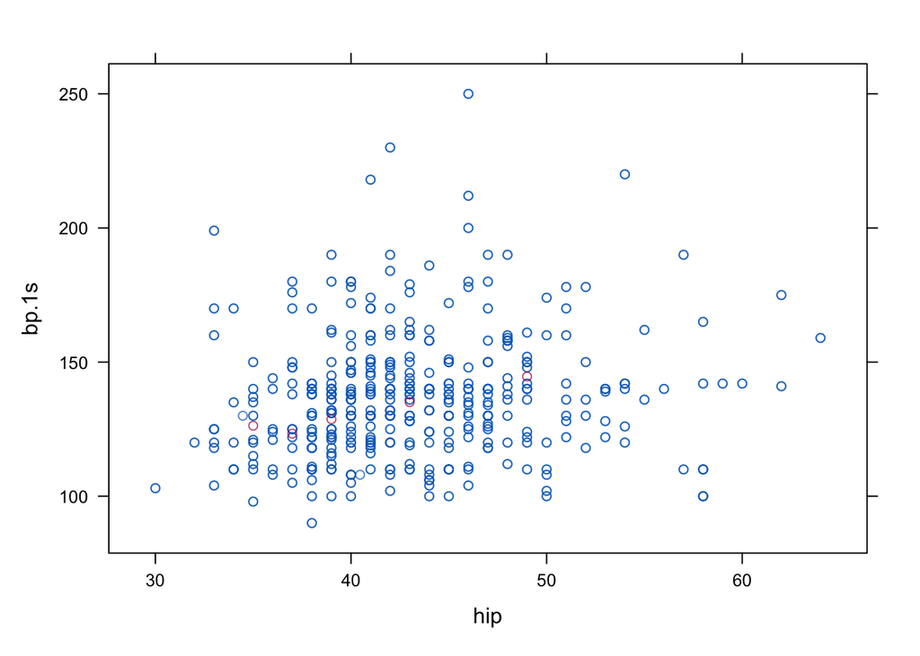

```r
xyplot(regr_imputated_data, bp.1s ~ hip)
```

## (c) Stochastic regression imputation and stepwise multiple regression

We use stochastic linear regression for numerical variables and polytomous logistic regression for categorical variables.

```r
library(mice)
stregr_imputated_data <- mice(data, defaultMethod = c("norm.nob", "polyreg", "polyreg", "polyreg"), m = 1, maxit = 20, printFlag = FALSE)
fit <- lm(data = complete(stregr_imputated_data), bp.1s ~ location + age + gender + height + weight + frame + waist + hip + time.ppn)
library(MASS)
step <- stepAIC(fit, direction = "both")
```

```
## Start:  AIC=2433.62
## bp.1s ~ location + age + gender + height + weight + frame + waist +
##     hip + time.ppn
##
##            Df Sum of Sq    RSS    AIC
## - height    1       3.3 160030 2431.6
## - location  1      13.5 160040 2431.7
## - gender    1     263.7 160290 2432.3
## - waist     1     334.5 160361 2432.5
## - weight    1     359.3 160386 2432.5
## - frame     2    1219.4 161246 2432.7
## - hip       1     679.7 160706 2433.3
## <none>                  160027 2433.6
## - time.ppn  1    1002.5 161029 2434.1
## - age       1   26527.0 186554 2493.4
##
## Step:  AIC=2431.62
## bp.1s ~ location + age + gender + weight + frame + waist + hip +
##     time.ppn
##
##            Df Sum of Sq    RSS    AIC
## - location  1      16.1 160046 2429.7
## - waist     1     331.6 160361 2430.5
## - weight    1     381.5 160411 2430.6
## - frame     2    1221.9 161252 2430.7
## - gender    1     430.8 160461 2430.7
## - hip       1     685.1 160715 2431.3
## <none>                  160030 2431.6
## - time.ppn  1    1010.2 161040 2432.2
## + height    1       3.3 160027 2433.6
## - age       1   26544.2 186574 2491.5
##
## Step:  AIC=2429.66
## bp.1s ~ age + gender + weight + frame + waist + hip + time.ppn
##
##            Df Sum of Sq    RSS    AIC
## - waist     1     348.1 160394 2428.5
## - weight    1     370.9 160417 2428.6
## - frame     2    1214.2 161260 2428.7
## - gender    1     417.0 160463 2428.7
```

[output cut: 51 more lines]

```
##
## Step:  AIC=2424.93
## bp.1s ~ age + hip + time.ppn
##
##            Df Sum of Sq    RSS    AIC
## <none>                  162150 2424.9
## - time.ppn  1       813 162963 2424.9
## + frame     2      1351 160798 2425.6
## + gender    1       434 161715 2425.8
## + waist     1       359 161791 2426.0
## + height    1        98 162052 2426.7
## + weight    1        28 162122 2426.9
## + location  1        12 162138 2426.9
## - hip       1      3773 165923 2432.2
## - age       1     40002 202151 2511.8
```

```r
step$anova
```

| Step | Df | Deviance | Resid. Df | Resid. Dev | AIC |
| --- | --- | --- | --- | --- | --- |
|  | NA | NA | 392 | 160026.6 | 2433.616 |
| - height | 1 | 3.276549 | 393 | 160029.8 | 2431.624 |
| - location | 1 | 16.103553 | 394 | 160045.9 | 2429.665 |
| - waist | 1 | 348.116611 | 395 | 160394.1 | 2428.540 |
| - weight | 1 | 145.857031 | 396 | 160539.9 | 2426.907 |
| - gender | 1 | 258.528500 | 397 | 160798.4 | 2425.555 |
| - frame | 2 | 1351.267109 | 399 | 162149.7 | 2424.928 |

```r
summary(step)
```

```
##
## Call:
## lm(formula = bp.1s ~ age + hip + time.ppn, data = complete(stregr_imputated_data))
##
## Residuals:
##     Min      1Q  Median      3Q     Max
## -55.395 -13.050  -1.015   8.767  93.583
##
## Coefficients:
##              Estimate Std. Error t value Pr(>|t|)
## (Intercept) 86.381184   8.421435  10.257  < 2e-16 ***
## age          0.611838   0.061669   9.921  < 2e-16 ***
## hip          0.544283   0.178621   3.047  0.00246 **
## time.ppn    -0.004622   0.003267  -1.415  0.15792
## ---
## Signif. codes:  0 '***' 0.001 '**' 0.01 '*' 0.05 '.' 0.1 ' ' 1
##
## Residual standard error: 20.16 on 399 degrees of freedom
## Multiple R-squared:  0.2193, Adjusted R-squared:  0.2134
## F-statistic: 37.36 on 3 and 399 DF,  p-value: < 2.2e-16
```

With stochastic regression imputation, `hip` is again introduced as an important explanatory variable. Therefore we are interested in analysing the relationship between `bp.1s` and `hip`:

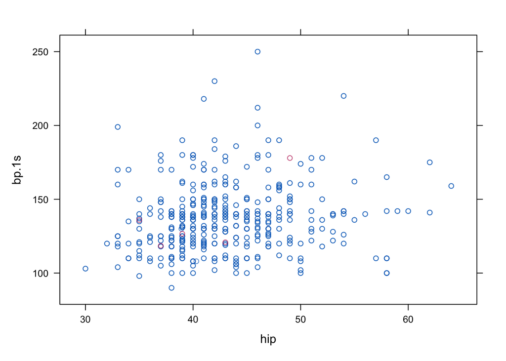

```r
xyplot(stregr_imputated_data, bp.1s ~ hip)
```

## (d) Random number imputation and stepwise multiple regression

```r
library(mice)
rand_imputated_data <- mice(data, defaultMethod = c("sample", "sample", "sample", "sample"), m = 1, maxit = 20, printFlag = FALSE)
fit <- lm(data = complete(rand_imputated_data), bp.1s ~ location + age + gender + height + weight + frame + waist + hip + time.ppn)
library(MASS)
step <- stepAIC(fit, direction = "both")
```

```
## Start:  AIC=2439.2
## bp.1s ~ location + age + gender + height + weight + frame + waist +
##     hip + time.ppn
##
##            Df Sum of Sq    RSS    AIC
## - location  1      17.7 162275 2437.2
## - weight    1      67.4 162325 2437.4
## - waist     1     242.6 162500 2437.8
## - height    1     261.7 162519 2437.8
## - hip       1     372.2 162630 2438.1
## - time.ppn  1     630.5 162888 2438.8
## - gender    1     643.3 162901 2438.8
## - frame     2    1539.3 163797 2439.0
## <none>                  162257 2439.2
## - age       1   26815.5 189073 2498.8
##
## Step:  AIC=2437.24
## bp.1s ~ age + gender + height + weight + frame + waist + hip +
##     time.ppn
##
##            Df Sum of Sq    RSS    AIC
## - weight    1      65.7 162341 2435.4
## - height    1     247.1 162522 2435.8
## - waist     1     260.2 162535 2435.9
## - hip       1     355.4 162631 2436.1
## - time.ppn  1     613.5 162889 2436.8
## - gender    1     625.7 162901 2436.8
## - frame     2    1528.0 163803 2437.0
## <none>                  162275 2437.2
## + location  1      17.7 162257 2439.2
## - age       1   26803.9 189079 2496.8
##
## Step:  AIC=2435.4
## bp.1s ~ age + gender + height + frame + waist + hip + time.ppn
##
##            Df Sum of Sq    RSS    AIC
## - waist     1     195.2 162536 2433.9
## - hip       1     301.4 162642 2434.2
## - height    1     387.4 162728 2434.4
## - gender    1     567.8 162909 2434.8
```

[output cut: 66 more lines]

```
##
## Step:  AIC=2430.95
## bp.1s ~ age + hip
##
##            Df Sum of Sq    RSS    AIC
## <none>                  165412 2430.9
## + frame     2      1604 163808 2431.0
## + time.ppn  1       488 164924 2431.8
## + gender    1       424 164988 2431.9
## + waist     1       303 165108 2432.2
## + weight    1        58 165353 2432.8
## + location  1         5 165407 2432.9
## + height    1         1 165410 2432.9
## - hip       1      3650 169062 2437.8
## - age       1     39863 205274 2516.0
```

```r
step$anova
```

| Step | Df | Deviance | Resid. Df | Resid. Dev | AIC |
| --- | --- | --- | --- | --- | --- |
|  | NA | NA | 392 | 162257.4 | 2439.195 |
| - location | 1 | 17.74544 | 393 | 162275.1 | 2437.239 |
| - weight | 1 | 65.68764 | 394 | 162340.8 | 2435.402 |
| - waist | 1 | 195.22220 | 395 | 162536.0 | 2433.887 |
| - height | 1 | 325.78210 | 396 | 162861.8 | 2432.693 |
| - gender | 1 | 329.18623 | 397 | 163191.0 | 2431.507 |
| - time.ppn | 1 | 616.72123 | 398 | 163807.7 | 2431.027 |
| - frame | 2 | 1603.78747 | 400 | 165411.5 | 2430.954 |

```r
summary(step)
```

```
##
## Call:
## lm(formula = bp.1s ~ age + hip, data = complete(rand_imputated_data))
##
## Residuals:
##     Min      1Q  Median      3Q     Max
## -57.813 -13.156  -1.720   8.895  94.931
##
## Coefficients:
##             Estimate Std. Error t value Pr(>|t|)
## (Intercept) 85.33520    8.29730  10.285  < 2e-16 ***
## age          0.61049    0.06218   9.818  < 2e-16 ***
## hip          0.53386    0.17969   2.971  0.00315 **
## ---
## Signif. codes:  0 '***' 0.001 '**' 0.01 '*' 0.05 '.' 0.1 ' ' 1
##
## Residual standard error: 20.34 on 400 degrees of freedom
## Multiple R-squared:  0.2092, Adjusted R-squared:  0.2053
## F-statistic: 52.91 on 2 and 400 DF,  p-value: < 2.2e-16
```

# Question 4

We select `bp.2s` as the response variable.

As in question 3, we fit a linear model to the data with the incomplete cases deleted. The purpose of this step is to allow for a comparison of different imputation methods relative to complete case analysis. To conduct the complete case analysis, we fit a linear model on the data, ignoring any case with `NA` in any of the variables, and we conduct a stepwise regression model selection based on AIC.

```r
library(MASS)
ccfit <- lm(data = na.omit(data[,!(colnames(data) %in% "bp.1s")]), bp.2s ~ location + age + gender + height + weight + frame + waist + hip + time.ppn)
ccstep <- stepAIC(ccfit, direction = "both", trace = 0)
ccstep$anova
```

| Step | Df | Deviance | Resid. Df | Resid. Dev | AIC |
| --- | --- | --- | --- | --- | --- |
|  | NA | NA | 124 | 53580.24 | 829.7942 |
| - frame | 2 | 76.705085 | 126 | 53656.94 | 825.9873 |
| - location | 1 | 0.796784 | 127 | 53657.74 | 823.9893 |
| - hip | 1 | 4.018433 | 128 | 53661.76 | 821.9994 |
| - gender | 1 | 13.371912 | 129 | 53675.13 | 820.0331 |
| - height | 1 | 90.266852 | 130 | 53765.40 | 818.2599 |

```r
summary(ccstep)
```

```
##
## Call:
## lm(formula = bp.2s ~ age + weight + waist + time.ppn, data = na.omit(data[,
##     !(colnames(data) %in% "bp.1s")]))
##
## Residuals:
##     Min      1Q  Median      3Q     Max
## -48.726 -12.211  -4.242   9.884  75.102
##
## Coefficients:
##               Estimate Std. Error t value Pr(>|t|)
## (Intercept) 112.147651  13.780699   8.138 2.82e-13 ***
## age           0.531195   0.127681   4.160 5.74e-05 ***
## weight       -0.117268   0.082579  -1.420    0.158
## waist         1.015679   0.596411   1.703    0.091 .
## time.ppn     -0.015539   0.005947  -2.613    0.010 *
## ---
## Signif. codes:  0 '***' 0.001 '**' 0.01 '*' 0.05 '.' 0.1 ' ' 1
##
## Residual standard error: 20.34 on 130 degrees of freedom
## Multiple R-squared:  0.2126, Adjusted R-squared:  0.1883
## F-statistic: 8.774 on 4 and 130 DF,  p-value: 2.658e-06
```

Therefore, in complete case analysis, the model selected is `bp.2s ~ age + weight + waist + time.ppn`

## (a) Mean imputation and model selection

```r
library(mice)
library(MASS)
mean_imputated_data <- mice(data, defaultMethod = c("mean", "pmm", "pmm", "pmm"), m = 1, maxit = 20, printFlag = FALSE)
fit <- lm(data = complete(mean_imputated_data), bp.2s ~ location + age + gender + height + weight + frame + waist + hip + time.ppn)
step <- stepAIC(fit, direction = "both", trace = 0)
step$anova
```

| Step | Df | Deviance | Resid. Df | Resid. Dev | AIC |
| --- | --- | --- | --- | --- | --- |
|  | NA | NA | 392 | 66164.62 | 2077.689 |
| - frame | 2 | 39.65153319 | 394 | 66204.27 | 2073.930 |
| - location | 1 | 0.08504304 | 395 | 66204.36 | 2071.931 |
| - hip | 1 | 0.13843286 | 396 | 66204.50 | 2069.932 |
| - gender | 1 | 224.61181656 | 397 | 66429.11 | 2069.296 |
| - height | 1 | 102.28543130 | 398 | 66531.39 | 2067.917 |

```r
summary(step)
```

```
##
## Call:
## lm(formula = bp.2s ~ age + weight + waist + time.ppn, data = complete(mean_imputated_data))
##
## Residuals:
##     Min      1Q  Median      3Q     Max
## -49.868  -4.198   0.186   3.318  79.587
##
## Coefficients:
##               Estimate Std. Error t value Pr(>|t|)
## (Intercept) 140.331744   4.731890  29.657  < 2e-16 ***
## age           0.147949   0.042642   3.470 0.000578 ***
## weight       -0.067135   0.032044  -2.095 0.036794 *
## waist         0.460005   0.228043   2.017 0.044347 *
## time.ppn     -0.003492   0.002096  -1.666 0.096566 .
## ---
## Signif. codes:  0 '***' 0.001 '**' 0.01 '*' 0.05 '.' 0.1 ' ' 1
##
## Residual standard error: 12.93 on 398 degrees of freedom
## Multiple R-squared:  0.0675, Adjusted R-squared:  0.05812
## F-statistic: 7.202 on 4 and 398 DF,  p-value: 1.318e-05
```

The final selected is the same as that in complete case analysis.

## (b) Regression imputation and model selection

```r
library(mice)
library(MASS)
regr_imputated_data <- mice(data, defaultMethod = c("norm.predict", "polyreg", "polyreg", "polyreg"), m = 1, maxit = 20, printFlag = FALSE)
fit <- lm(data = complete(regr_imputated_data), bp.2s ~ location + age + gender + height + weight + frame + waist + hip + time.ppn)
step <- stepAIC(fit, direction = "both", trace = 0)
step$anova
```

| Step | Df | Deviance | Resid. Df | Resid. Dev | AIC |
| --- | --- | --- | --- | --- | --- |
|  | NA | NA | 392 | 141304.5 | 2383.474 |
| - gender | 1 | 1.595674 | 393 | 141306.1 | 2381.478 |
| - weight | 1 | 4.717737 | 394 | 141310.8 | 2379.492 |
| - frame | 2 | 955.139500 | 396 | 142266.0 | 2378.206 |
| - height | 1 | 543.617325 | 397 | 142809.6 | 2377.743 |
| - hip | 1 | 457.757457 | 398 | 143267.4 | 2377.033 |

```r
summary(step)
```

```
##
## Call:
## lm(formula = bp.2s ~ location + age + waist + time.ppn, data = complete(regr_imputated_data))
##
## Residuals:
##     Min      1Q  Median      3Q     Max
## -53.237 -12.249  -1.263   8.285  96.921
##
## Coefficients:
##                 Estimate Std. Error t value Pr(>|t|)
## (Intercept)    84.384449   6.911502  12.209  < 2e-16 ***
## locationLouisa  4.761434   1.913971   2.488 0.013265 *
## age             0.585501   0.058709   9.973  < 2e-16 ***
## waist           0.642905   0.167840   3.830 0.000149 ***
## time.ppn       -0.009936   0.003111  -3.194 0.001514 **
## ---
## Signif. codes:  0 '***' 0.001 '**' 0.01 '*' 0.05 '.' 0.1 ' ' 1
##
## Residual standard error: 18.97 on 398 degrees of freedom
## Multiple R-squared:  0.2742, Adjusted R-squared:  0.2669
## F-statistic: 37.58 on 4 and 398 DF,  p-value: < 2.2e-16
```

With regression imputation, `location` is added as an important explanatory variable in the final model.

## (c) Stochastic regression imputation and model selection

```r
library(mice)
library(MASS)
stregr_imputated_data <- mice(data, defaultMethod = c("norm.nob", "polyreg", "polyreg", "polyreg"), m = 1, maxit = 20, printFlag = FALSE)
fit <- lm(data = complete(stregr_imputated_data), bp.2s ~ location + age + gender + height + weight + frame + waist + hip + time.ppn)
step <- stepAIC(fit, direction = "both", trace = 0)
step$anova
```

| Step | Df | Deviance | Resid. Df | Resid. Dev | AIC |
| --- | --- | --- | --- | --- | --- |
|  | NA | NA | 392 | 173328.3 | 2465.795 |
| - height | 1 | 58.36174 | 393 | 173386.7 | 2463.930 |
| - gender | 1 | 69.90301 | 394 | 173456.6 | 2462.093 |
| - hip | 1 | 65.42135 | 395 | 173522.0 | 2460.245 |
| - weight | 1 | 370.21500 | 396 | 173892.2 | 2459.104 |
| - frame | 2 | 1593.07756 | 398 | 175485.3 | 2458.779 |

```r
summary(step)
```

```
##
## Call:
## lm(formula = bp.2s ~ location + age + waist + time.ppn, data = complete(stregr_imputated_data))
##
## Residuals:
##     Min      1Q  Median      3Q     Max
## -58.351 -13.755  -0.513  11.309  96.369
##
## Coefficients:
##                 Estimate Std. Error t value Pr(>|t|)
## (Intercept)    85.034006   7.645404  11.122  < 2e-16 ***
## locationLouisa  3.867486   2.116836   1.827 0.068447 .
## age             0.562270   0.064965   8.655  < 2e-16 ***
## waist           0.672832   0.185821   3.621 0.000332 ***
## time.ppn       -0.010770   0.003433  -3.137 0.001835 **
## ---
## Signif. codes:  0 '***' 0.001 '**' 0.01 '*' 0.05 '.' 0.1 ' ' 1
##
## Residual standard error: 21 on 398 degrees of freedom
## Multiple R-squared:  0.2275, Adjusted R-squared:  0.2197
## F-statistic:  29.3 on 4 and 398 DF,  p-value: < 2.2e-16
```

## (d) Random number imputation and model selection

```r
library(mice)
library(MASS)
rand_imputated_data <- mice(data, defaultMethod = c("sample", "sample", "sample", "sample"), m = 1, maxit = 20, printFlag = FALSE)
fit <- lm(data = complete(rand_imputated_data), bp.2s ~ location + age + gender + height + weight + frame + waist + hip + time.ppn)
step <- stepAIC(fit, direction = "both", trace = 0)
step$anova
```

| Step | Df | Deviance | Resid. Df | Resid. Dev | AIC |
| --- | --- | --- | --- | --- | --- |
|  | NA | NA | 392 | 209448.4 | 2542.078 |
| - frame | 2 | 1000.58944 | 394 | 210449.0 | 2539.999 |
| - age | 1 | 5.23961 | 395 | 210454.3 | 2538.009 |
| - location | 1 | 88.09665 | 396 | 210542.4 | 2536.178 |
| - hip | 1 | 178.49297 | 397 | 210720.9 | 2534.519 |
| - gender | 1 | 661.59313 | 398 | 211382.5 | 2533.783 |
| - height | 1 | 269.53475 | 399 | 211652.0 | 2532.296 |

```r
summary(step)
```

```
##
## Call:
## lm(formula = bp.2s ~ weight + waist + time.ppn, data = complete(rand_imputated_data))
##
## Residuals:
##     Min      1Q  Median      3Q     Max
## -56.346 -14.359  -4.136  10.289  86.402
##
## Coefficients:
##               Estimate Std. Error t value Pr(>|t|)
## (Intercept) 152.805368   8.282415  18.449  < 2e-16 ***
## weight       -0.197126   0.053244  -3.702 0.000244 ***
## waist         0.984538   0.375095   2.625 0.009004 **
## time.ppn     -0.005685   0.003674  -1.547 0.122564
## ---
## Signif. codes:  0 '***' 0.001 '**' 0.01 '*' 0.05 '.' 0.1 ' ' 1
##
## Residual standard error: 23.03 on 399 degrees of freedom
## Multiple R-squared:  0.03987,    Adjusted R-squared:  0.03265
## F-statistic: 5.522 on 3 and 399 DF,  p-value: 0.001006
```

# Conclusion